# Chapter 6: One-Sample Inference for Means with R

Author

Firstname Lastname

This help sheet shows how to use built-in R procedures to carry out examples in Section 6.2. The primary R procedure for $t$ inference is `t.test()`.

## 6.2-CI Confidence Intervals for a Mean Using the $t$-distribution

**Example 6.13**

Use the data on airborne times (in minutes) for **Flight433_3e** to find a 95% confidence interval for the mean flight time on this route from Boston to San Francisco.

**Answer:**

The variable of interest is *AirTime* in the data frame **Flight433_3e**.

First look at the data frame:

```r
head(Flight433_3e)
```

```
  AirTime
1     377
2     367
3     368
4     362
5     391
6     388
```

Because the sample size of $n=28$ is not large enough for the CLT for means to apply, before using the t-distribution we should check a plot of the data for signs of extreme outliers or heavy skewness. The dotplot below shows no reasons for serious concerns.

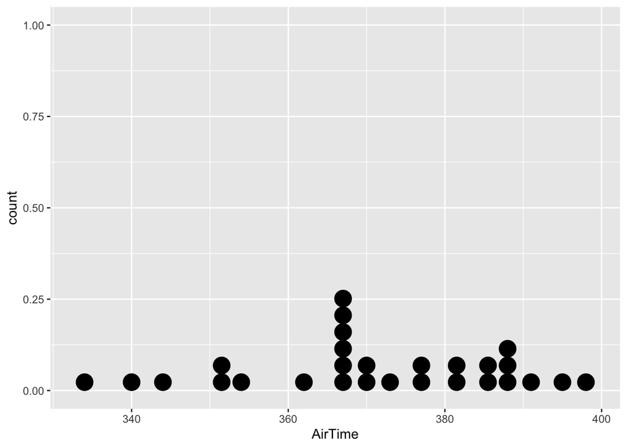

```r
gf_dotplot(~AirTime, data = Flight433_3e)
```

Use the `t.test()` function to obtain the desired confidence interval. We show how to specify the confidence interval

```r
t.test(~AirTime, conf.level = .95, data = Flight433_3e)
```

```
    One Sample t-test

data:  AirTime
t = 117.35, df = 27, p-value < 2.2e-16
alternative hypothesis: true mean is not equal to 0
95 percent confidence interval:
 364.6184 377.5959
sample estimates:
mean of x
 371.1071
```

Based on these data, we are 95% sure that the mean airborne time for Flight 433 from Boston to San Francisco is between 364.6 and 377.6 minutes.

**Example 6.14**

```r
head(CommuteAtlanta)
```

```
     City Age Distance Time Sex
1 Atlanta  19       10   15   M
2 Atlanta  55       45   60   M
3 Atlanta  48       12   45   M
4 Atlanta  45        4   10   F
5 Atlanta  48       15   30   F
6 Atlanta  43       33   60   M
```

#### Confidence interval using t

```r
t.test(~Time, data = CommuteAtlanta, conf.level = .99)
```

```
    One Sample t-test

data:  Time
t = 31.418, df = 499, p-value < 2.2e-16
alternative hypothesis: true mean is not equal to 0
99 percent confidence interval:
 26.7142 31.5058
sample estimates:
mean of x
    29.11
```

> “Remember that the key idea when constructing a confidence interval is to use a method that produces an interval containing the true mean some fixed proportion of the time. That is true for both the formula-based $t$ and the boostrap intervals, even though they give slightly different intervals for any particular sample. The advantage of the $t$-interval is that it is most commonly used in practice when estimating a mean. The advantage of the bootstrap methods is that they remain valid in cases where conditions, such as normality for a small sample, might be questionable. Also, the bootstrap methods are flexible enough to use for almost all parameters, while the $t$-distribution only works for certain parameters such as the mean.” (Lock5)

**Example 6.15**

A plot of the data on rent prices of **ManhattanApartments** suggests the normal assumption is clearly violated because of the strong right skewness and potential outliers with a small sample size ($n=20$). Instead, we would use the bootstrap method for a single mean from Chapter 3.

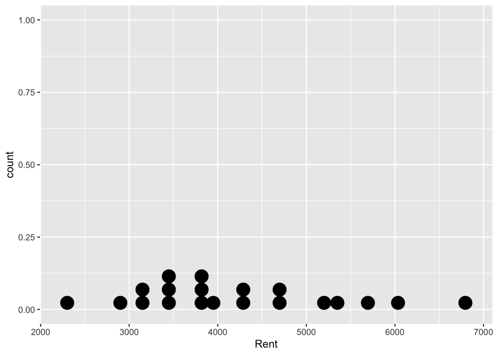

```r
gf_dotplot(~Rent, data = ManhattanApartments)
```

## 6.2-HT Test for a Single Mean

**Example 6.17**

```r
head(BodyTemp50)
```

```
  BodyTemp Pulse Sex
1     97.6    69   0
2     99.4    77   1
3     99.0    75   0
4     98.8    84   1
5     98.0    71   0
6     98.9    76   1
```

The relevant hypotheses are $H_0:\mu=98.6$ vs $H_a:\mu \ne 98.6$ where $\mu$ is the mean body temperature for all healthy humans. The figure below is a histogram of this sample of body temperatures. The plot raises no concerns about a lack of normality in the population and the sample size (n = 50) is quite large, so a $t$-distribution is appropriate for this test.

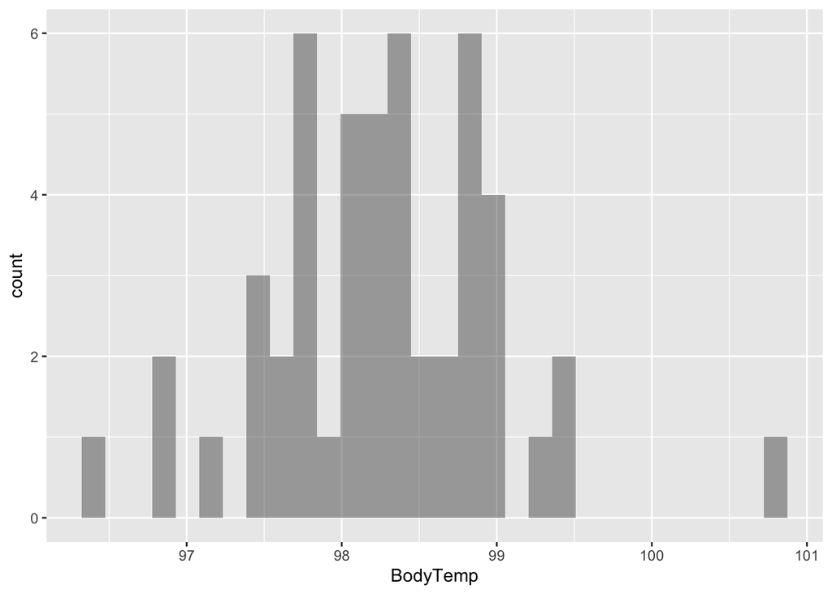

```r
gf_histogram(~BodyTemp, data = BodyTemp50)
```

Use the R function `t.test()` to carry out the procedure:

```r
t.test(~BodyTemp, mu = 98.6, data = BodyTemp50)
```

```
    One Sample t-test

data:  BodyTemp
t = -3.1414, df = 49, p-value = 0.002851
alternative hypothesis: true mean is not equal to 98.6
95 percent confidence interval:
 98.0425 98.4775
sample estimates:
mean of x
    98.26
```

We obtain $t=-3.1414$ and 2-sided $p$-value=0.00285 for a $t$ distribution with 50-1=49 degrees of freedom. We have strong evidence that mean body temperate is not 98.6.

**Example 6.18**

TThe **FloridaLakes** dataset includes information on alkalinity values for 53 Florida lakes. The mean of the values is $\bar x = 37.5$ mg/L with standard deviation $s = 38.20$. Test to see if this sample provides evidence that the average alkalinity of all Florida lakes is greater than 35 mg/L.

**Solution:**

The figure below shows a histogram of the alkalinity values.

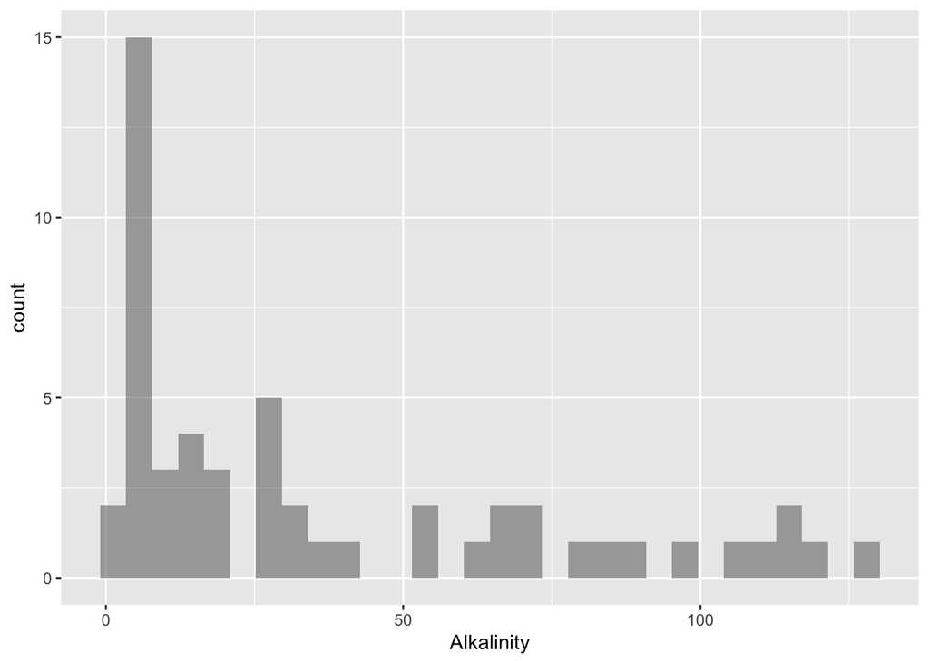

```r
gf_histogram(~Alkalinity, data = FloridaLakes)
```

We see in that the alkalinity values in this sample are very skewed and don’t seem to follow a normal distribution at all. Nonetheless, the sample size of $n = 53$ is large enough that the CLT for means is relevant so a $t$-test is probably valid. The hypotheses for the test are:

$$\begin{align}
H_0: &\mu=35 \\
H_a: &\mu>35
\end{align}$$

Use the `t.test()` function specifying the null hypothesis and the one-sided tail:

```r
t.test(~Alkalinity, mu=35, alt = "greater", data = FloridaLakes)
```

```
    One Sample t-test

data:  Alkalinity
t = 0.48216, df = 52, p-value = 0.3159
alternative hypothesis: true mean is greater than 35
95 percent confidence interval:
 28.74199      Inf
sample estimates:
mean of x
 37.53019
```

We obtain $t=0.482$ on $df=53-1=52$ degrees of freedom. The corresponding $p$-value is given a $p=0.316$. We have no evidence to reject the null hypothesis in favor of the alternative.

Note the use of “greater” for the alternative. Another option is to use “less” for a less than alternative. The default value is “two.sided”.